# Multivariate Statistics and Methodology with R

Introduction to the course

Aja Murray; Aja.Murray@ed.ac.uk

11/01/2021

# What to expect

- The team
- Course structure and content
- Assessment
- How to study

# The Multivariate team - lecturers

- Dan Mirman
- Profile: https://www.ed.ac.uk/profile/dr-daniel-mirman
- Email: Daniel.Mirman@ed.ac.uk
- Multi-level modeling (weeks 1-5)

# The Multivariate team - lecturers

- Aja Murray (Course organiser)
- Profile: https://www.ed.ac.uk/profile/aja-murray
- Email: Aja.Murray@ed.ac.uk
- Structural equation modeling (weeks 7-11)

# The Multivariate team - teaching co-ordinators

- Jo King

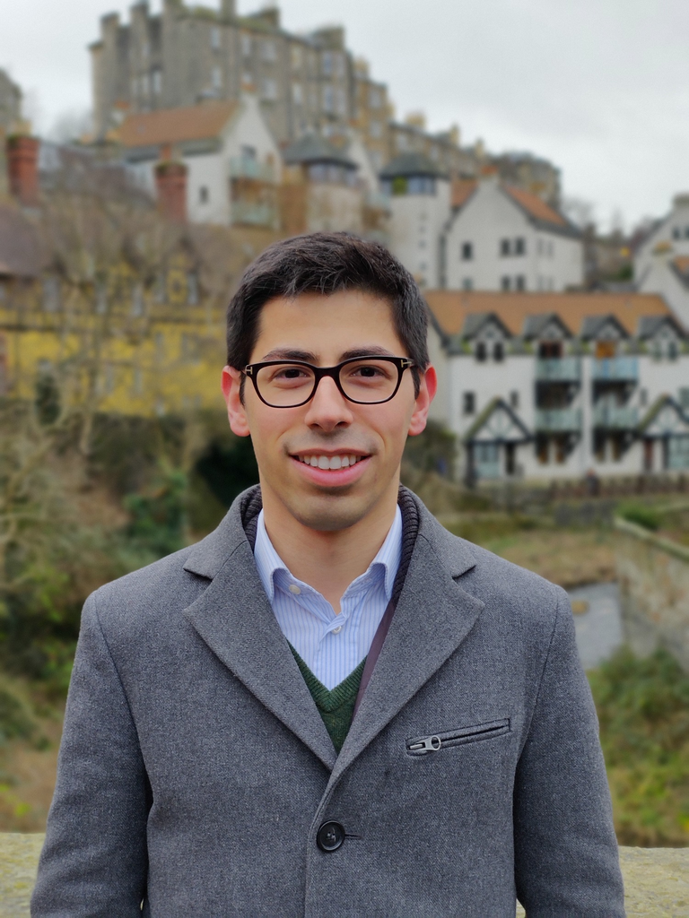

- Umberto Noe

(both pg.ppls.stats@ed.ac.uk )

# Asynchronous activities

- Lectures
  - The week’s lecture material (available noon previous Friday)
  - In short chunks
  - Will include both statistics theory and R
- Practical exercises
  - R-based exercises to put learning into practice
  - May also include material not in lectures
  - Preparation for the assessment
- Discussion forum
  - Post any questions on course content here
  - Now using Piazza
  - https://media.ed.ac.uk/media/Intro+to+Piazza+Discussion+Forum/1_0tml4z1q

# Synchonrous sessions

- Drop-in sessions
  - Online drop-in sessions where you can get help with the practical exercises
  - Served by tutors, teaching co-ordinators and lecturers (where possible)
- Live Q&As with lecturers (including live coding)
  - Each week Monday 3pm
  - Lecturer for that week answers questions on lecture content
- Office hours
  - Go to: https://gather.town/app/Ia0fGeJ2FPslx4tM/msmr
  - Umberto:Thursday 10:00-11:00
  - Jo: Friday 10:00-11:00
  - Dan (weeks 1-5): Wednesday 15:00-16:00
  - Aja (weeks 7-11): Thursday 11:00-12:00

# Other

- Weekly digest will be posted to remind you of your goals/activities for the week

# Course content - first block

- First five weeks will be **mixed effects models**
  - AKA *multilevel models*, *random coefficient models*, *hierarchical models*, *mixed models*
  - Taught by Dan Mirman

# Week 6

- Then a one week break reading week

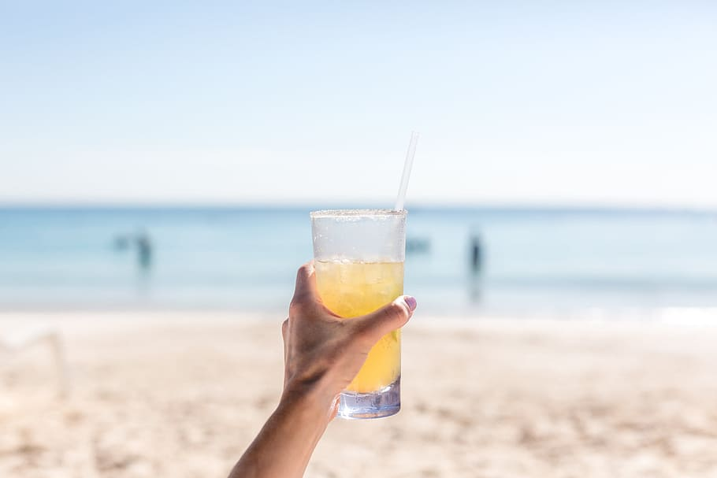

# Course content - second block

- Last five weeks will be *dimension reduction* and *latent variable modeling*
  - This will include:
    - Principal components analysis
    - Exploratory factor analysis
    - Confirmatory factor analysis
    - Path analysis
    - Full structural equation modeling
  - Taught by Aja Murray

# The assignment - overview

- 80% report, 20% quizzes
- Quizzes
  - 2 for each part of the course
  - Mark based on best of 3
- Report
  - Similar to USMR
  - Will draw on both sections of the course
  - We will give you data and a series of research questions to answer
  - Answers written up as a report, with R scripts submitted separately
  - More advice to follow later

# The assignment - what we’ll be looking for

- Can you select an appropriate method(s) to answer a research question?
- Are your choices well-justified?
- Can you correctly implement these methods in R?
- Can you interpret your findings?

# Assignment dates

- Assignment released on: 2/04/2020
- Assignment due date: 30/04/2020

# How to study

- Watch the lecture recordings
- Ask questions at the Q&As and on discussion forum
  - (there are no stupid questions!)
- Come to the drop-in sessions
- Build up annotated R scripts
- Engage with the suggested readings
- Use Google and the R help functions
  - even the most experienced coders use both *all the time*

# End

- Enjoy the course!